# threshold patch %s

## Threshold experiments

We’re using an averaged estimate of *cfin* biomass – 264 ug

The below code builds a comparison that evaluates the percentage of patch points for a variety of combinations of slope and base values.

**What range should base and slope vary between?**

- Base - from Camille’s work, we vary between 10K to 40K abundance
- Slope - varies from 0 (no increase) to 1000 (significant increase) in abundance.

```r
idw <- 264

threshold_method <- function(pdepth, base, slope) {
  (pdepth * slope + base) |>
    sapply(function(x) min(x, 1500000 * idw))
}

base_values <- seq(10000, 40000, length.out = 20) * idw
# based around estimate from provided graph
slope_values <- seq(0, 1000, length.out = 20) * idw
```

```r
ae_perc <- ae_dw |> select(Bathy_depth, dry_weight, lon, lat) |>
  mutate(pdepth = sapply(Bathy_depth, function(x) max(x-300, 0)))

get_perc_patch <- function(base, slope) {
  counts <- ae_perc |>
    mutate(patch = dry_weight >= threshold_method(pdepth, base, slope)) |>
    count(patch)

  counts[[2, 2]]/sum(counts$n)
}
```

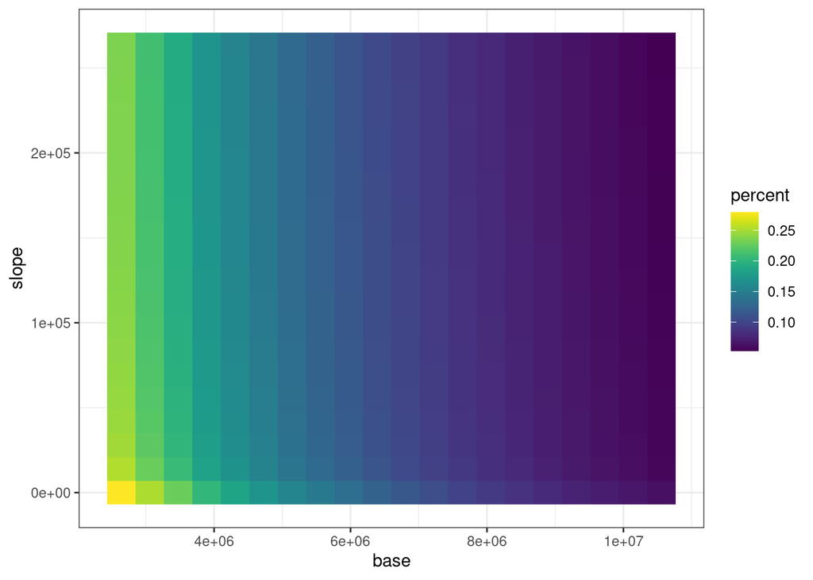

```r
percents <- expand.grid(base = base_values, slope = slope_values) |>
  rowwise() |>
  mutate(percent = get_perc_patch(base, slope))

ggplot(percents, aes(x = base, y = slope, fill = percent)) +
  geom_raster() +
  theme_bw() +
  viridis::scale_fill_viridis()
```

The clear takeaway from this graph is that the base threshold is overwhelmingly what determines percentage above/below threshold, rather than the slope of the line above 300 meters.

## Graph comparisons

How do plots vary with different bases?

- these plots only display **patch values**

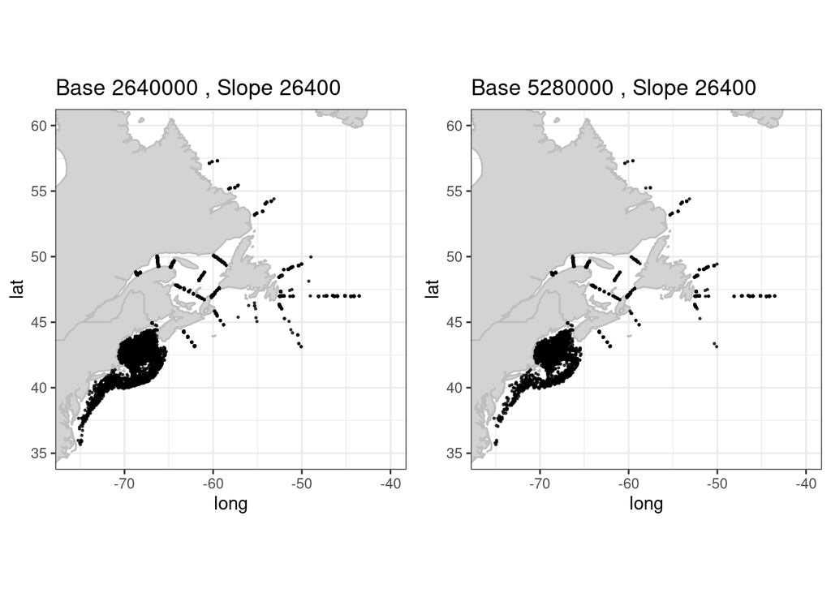

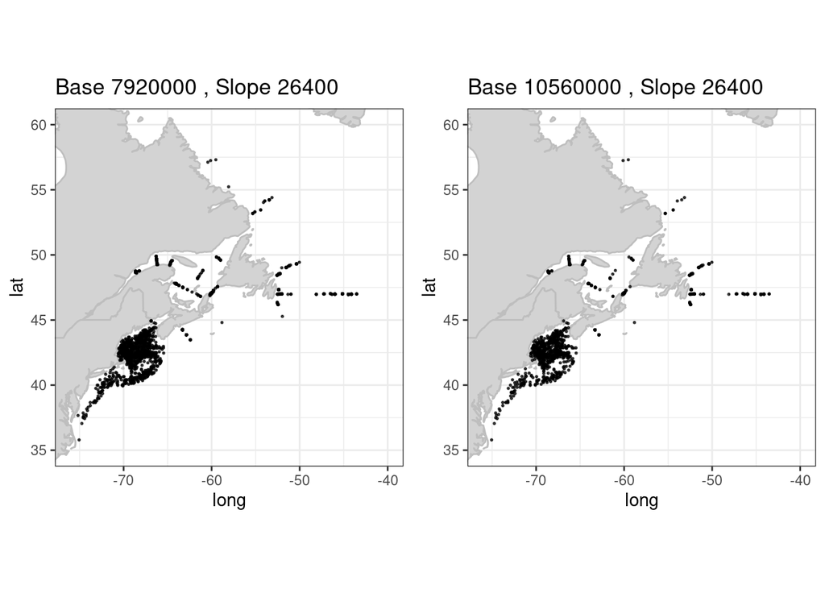

```r
base_vec2 = seq(10000, 40000, length.out = 4) * idw

slope = 100 * idw

ggpubr::ggarrange(
  plotlist = map(base_vec2, ~plot_base(.x, slope)),
  nrow = 1,
  ncol = 2,
  common.legend = TRUE,
  legend = "right") |>
  walk(print)
```

How do plots vary with differing slopes?

- these plots only display **patch values in areas over 300 meters**

When considering only points above 300 m, how does slope affect calculations?

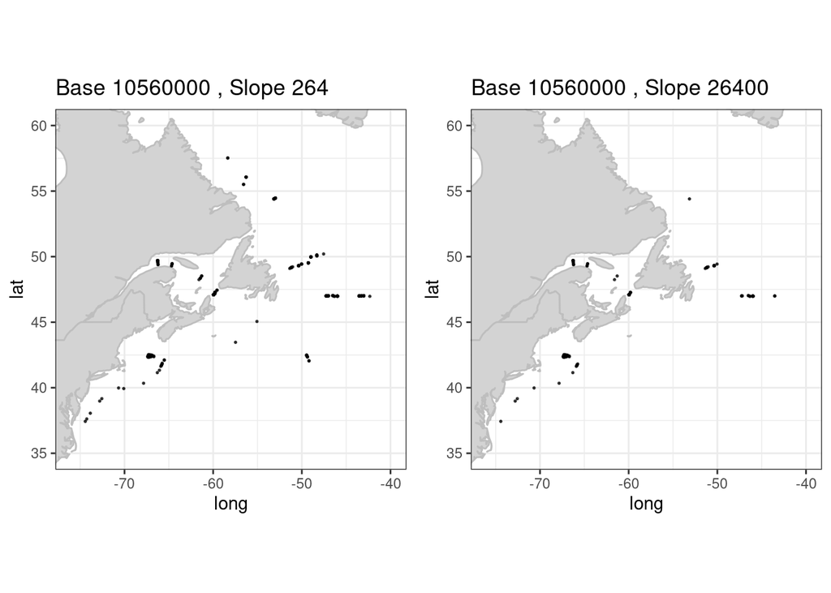

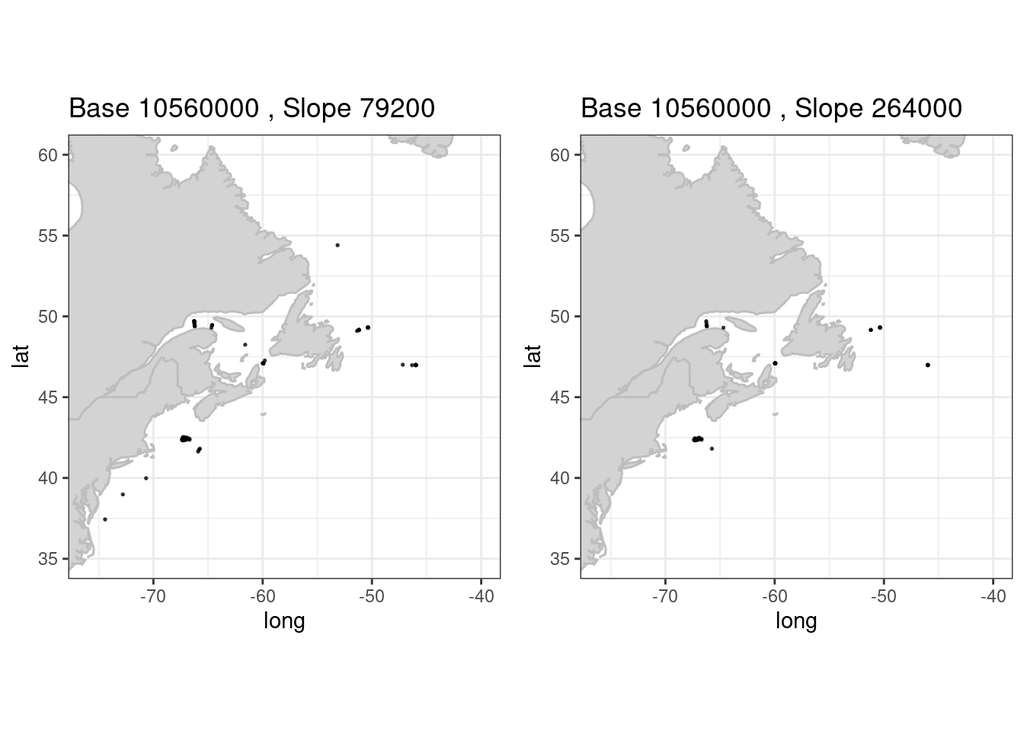

```r
ggpubr::ggarrange(
  plotlist = map(c(1, 100, 300, 1000) * idw,
                 ~plot_slope(40000*idw, .x)),
  nrow = 1,
  ncol = 2,
  common.legend = TRUE,
  legend = "right") |>
  walk(print)
```